# Exploratory Analysis

## The Study of Sleep and Work

### Authors

Leon Nguyen, Samarth Rao, Nicholas Chung, Jonathan Cao

### Date

Spring 2024

### Abstract

Our main question is how sleep amount correlates to someone’s earnings and age. To address this question we will be analyzing a dataset containing important statistics regarding factors such as the amount of sleep, age, time spent on work, etc.. We are concerned with this because there is a notion that wealthy people give up sleep to further their careers so we plan to analyze the data, and compare how work-life balance affects sleep patterns.

### Keywords

- Sleep amount
- Age
- Work-life Balance
- Work relationship

### Introduction

This project aims to find a correlation between the amount of sleep a person gets and work. Does age increase or decrease the amount of sleep a person gets? How does the nature of one’s job, particularly the level of work experience, affect sleep patterns? We will be exploring these questions to challenge the notion often perpetuated by successful individuals that sacrificing sleep is necessary to maximize career potential. On social media, it’s common to see influential business people, often making six-figure salaries, advocating for waking up before dawn and maintaining a sleep schedule that includes only 4-6 hours of rest per night, far below the amount recommended by scientists. These influencers swear by their schedules and guarantee success to those who follow their routines. However, this project seeks to explore the potential negative effects of such advice, especially for young, impressionable viewers. Consistently sacrificing sleep can impair daily functioning and long-term health. By answering these questions, we hope to provide a clearer understanding of how different levels of work experience impact sleep, thereby guiding individuals towards finding a sleep schedule that is both healthy and conducive to their career goals.

### Related Work

In our study we aim to see the relationship between a person’s age, and work-life, minutes worked, salary, and how it correlates to their sleep. There are a few articles/ research papers that look into the correlation between sleep and work and vice versa. These research articles focus on how sleep affects wages, as well as how long work hours can affect your sleep. This shows a two way relationship on how better sleep can improve your job, but also how your job life can affect your sleep. This is an important connection to learn about as sleep is an important necessity for our body to function and finding ways to correlate/improve everyday activities such as job to improve sleep can greatly benefit many in the industry who don’t have a good work-life balance. The first paper discusses work-life balance in South Korea, which is an interesting topic because of their different work values from those in the US. The second paper focuses on giving up working time for sleep is beneficial to efficiency and how more workplaces should adopt this strategy. The third paper focuses on the relationship between wages and sleep duration, whether that be increasing or decreasing alongside one another.

Linked Below are 3 research papers that discuss similar correlations…

- Choi, H., Lee, S., Jeon, M.-J., & Min, Y.-S. (2020, November 3). Relationship between long work hours and self-reported sleep disorders of non-shift daytime wage workers in South Korea: Data from the 5th Korean Working Conditions Survey. Annals of occupational and environmental medicine. https://www.ncbi.nlm.nih.gov/pmc/articles/PMC7779839/
- Gibson, M., & Shrader, J. (2018, December 1). Time use and labor productivity: The returns to sleep. MIT Press. https://direct.mit.edu/rest/article/100/5/783/58488/Time-Use-and-Labor-Productivity-The-Returns-to_sleep
- Sedigh G;Devlin RA;Grenier G;Deri Armstrong C; (n.d.). Revisiting the relationship between wages and sleep duration: The role of insomnia. Economics and human biology. https://pubmed.ncbi.nlm.nih.gov/27987490/

### The Dataset

> Where did you find the data? Please include a link to the data source
- The data set we’re using was found on [Kaggle](https://www.kaggle.com/datasets/kapturovalexander/sleep-patterns?resource=download)

> Who collected the data?
- The data was collected by Alexander Kapturov

> How was the data collected or generated?
- While we do not know the exact reason this dataset was collected, we can make an educated guess that this dataset was collected using surveys, or crowdsourcing to efficiently collect different data from a large sample group.

> Why was the data collected?
- Just like the previous question we do not have an exact answer, but we can assume that this dataset was to correlate how different factors and sleep are related to understand what can affect our sleep.

> How many observations (rows) are in your data?
- There are 706 rows in this dataset.

> How many features (columns) are in the data?
- There are 34 columns in this dataset.

> What, if any, ethical questions or questions of power do you need to consider when working with this data?
- While working with this dataset, we need to make sure that we don’t create biased analysis as this could lead to incorrect assumptions being made through a person’s characteristics and their sleep behavior which could be detrimental when those groups are trying to improve sleep habits.

> What are possible limitations or problems with this data? (at least 200 words)
- One possible limitation with this data is that we are unable to consider specific professions when analyzing the dataset. Since this feature is not included in the dataset, we instead need to analyze the amount of sleep with other relevant features such as time spent working. Another possible problem with this dataset is the noise (or outliers) in the dataset. Since it is very common for datasets to include outliers, these outliers may cause the results of our analysis to show inaccurate relationships. For example, there could be an individual in the dataset who has almost no work experience, but is naturally talented and is able to spend less time working. This could make it appear that less work experience means less time spent working when in actuality the relationship is less work experience means more time spent working due to inexperience. Another possible limitation is that since we do not know exactly where this dataset came from the dataset may represent people who are in a location where wages are on average higher. For example, Country A may have an extremely high average wage whereas Country B may have a lower average wage, however, if the dataset was collected from Country A it may lead us to believe that a higher wage has a much larger effect on the amount of sleep than it actually does.

### Implications

Following our research into the topic of how age and work-life correlates to the amount of sleep we have a few expected or possible implications. Firstly, one expected implication for policymakers is that they can take this research into consideration when on the topic of work hours at their company. For example, companies can utilize this research to create a more healthy work-life balance if it is discovered that less amount of sleep has a negative impact on the work quality. Secondly, another possible implication for policymakers is that they can utilize this research to decide proper wages based on how much an individual spends working. This can in turn influence a more productive environment as a higher wage may incentivize productivity. Finally, one other possible implication for designers of a workplace is that they can utilize this research to decide the effective amount of work hours that an employee should work based on their work experience and wage. For example, if it is discovered that an employee who has a good amount of sleep and high work experience is extremely effective in the workplace, designers can take this into consideration and maybe consider less working hours for those with higher experience in order to make the work produced even more effective.

### Limitations & Challenges

Some of the limitations and challenges with this dataset is that, we don’t have access to a column that contains the person’s occupation. Having access to this data, in addition to the data that we are currently analyzing, would allow us to make a stronger connection between work-life balance as we could understand different types and occupations (labor intensive, office/desk job), and how they could factor into our dataset. The fact that we do not have a lot of background information about our dataset, also limits our analysis, because where the data was collected and how it was collected could have a large influence on how we look at the data and results in general. For example, if we collected the data in a country, where working conditions are worse, then our data might tell us a different story and connection, then if we measured these data points in another country where working conditions are improved. While this does not stop us from making a correlation with our data, knowing this information could make our correlation more thorough and let us tell a better story with our data.

### Table: Correlation of Age, Sleep, Work, and Experience

| Age | Sleep (hrs/day) | Hours Worked per Day (5 days/wk) | Years of Experience |
| --- | --- | --- | --- |
| 23 | 7.40 | 6.81 | 3.41 |
| 24 | 8.13 | 6.12 | 3.81 |
| 25 | 7.53 | 6.60 | 5.20 |
| 26 | 7.86 | 7.18 | 7.19 |
| 27 | 7.72 | 7.38 | 7.33 |
| 28 | 7.81 | 6.45 | 8.64 |
| 29 | 7.82 | 7.45 | 9.46 |
| 30 | 7.78 | 7.23 | 10.36 |
| 31 | 7.48 | 7.80 | 11.42 |
| 32 | 7.62 | 7.19 | 13.21 |
| 33 | 7.57 | 7.31 | 13.29 |
| 34 | 8.30 | 6.72 | 15.06 |
| 35 | 7.84 | 7.01 | 16.00 |
| 36 | 7.13 | 8.20 | 17.65 |
| 37 | 7.71 | 8.54 | 18.06 |
| 38 | 7.72 | 7.65 | 19.43 |
| 39 | 7.59 | 7.93 | 19.57 |
| 40 | 7.93 | 6.85 | 20.69 |
| 41 | 7.63 | 8.22 | 20.67 |
| 42 | 7.79 | 8.31 | 23.33 |
| 43 | 7.65 | 7.61 | 26.18 |
| 44 | 7.73 | 7.24 | 26.08 |
| 45 | 7.94 | 6.23 | 26.92 |
| 46 | 8.06 | 7.47 | 27.33 |
| 47 | 7.60 | 6.76 | 29.07 |
| 48 | 7.48 | 6.37 | 30.60 |
| 49 | 8.13 | 6.32 | 30.23 |
| 50 | 7.49 | 8.12 | 32.11 |
| 51 | 8.09 | 5.85 | 33.75 |
| 52 | 7.97 | 6.98 | 34.35 |
| 53 | 7.72 | 7.68 | 34.00 |
| 54 | 7.77 | 7.25 | 34.19 |
| 55 | 7.80 | 6.44 | 36.56 |
| 56 | 7.96 | 7.81 | 38.87 |
| 57 | 8.16 | 5.85 | 39.50 |
| 58 | 7.83 | 5.73 | 42.11 |
| 59 | 7.88 | 7.13 | 41.67 |
| 60 | 8.36 | 7.27 | 42.80 |
| 61 | 7.80 | 6.20 | 42.00 |
| 62 | 8.28 | 4.90 | 45.50 |
| 63 | 8.73 | 1.85 | 50.50 |
| 64 | 8.06 | 5.00 | 44.33 |
| 65 | 9.21 | 3.85 | 51.00 |

This table displays how much work and experience affect the amount of sleep a person will get on average. Data with the same age are calculated into a set of data that is the average of everyone in the age group.

#### Purpose

By showing data of age, sleep, work hours, and experience side by side, we can easily see how these factors can affect someone’s sleep. Now if we are interested in a certain age or range, we can easily see all of the relevant data, which allows us to efficiently explore the nuances of work-life balance.

### Chart 1: How Age Relates To Hours Slept Per Day

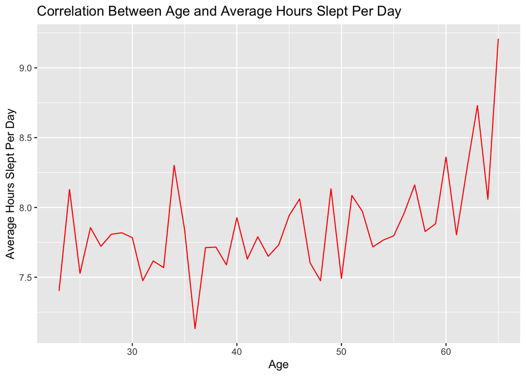

This chart displays how the hours slept per day changes as you grow older.

#### Purpose

There are multiple reasons we added this chart. The main question that we want to answer is the factors that impact a work-life balance across multiple age groups. Through prior analysis we know that there is a correlation between age and experience. As the age of a person increases, so does their experience. So through this chart, not only can we see how different ages have different sleep preferences, but also the sleeping habits of older more experienced people.

#### Insights

From the lines in the graph you can see that as the age increases, we see a increase in the number of hours slept on average. This leans us to a conclusions that shows how, as you the older, with more experience, the number of hours you sleep increases. Going back our question on hand we can see how different people in the industry have different sleep factors and habits

### Chart 2: Natural Logarithm of Wages Compared to Sleep

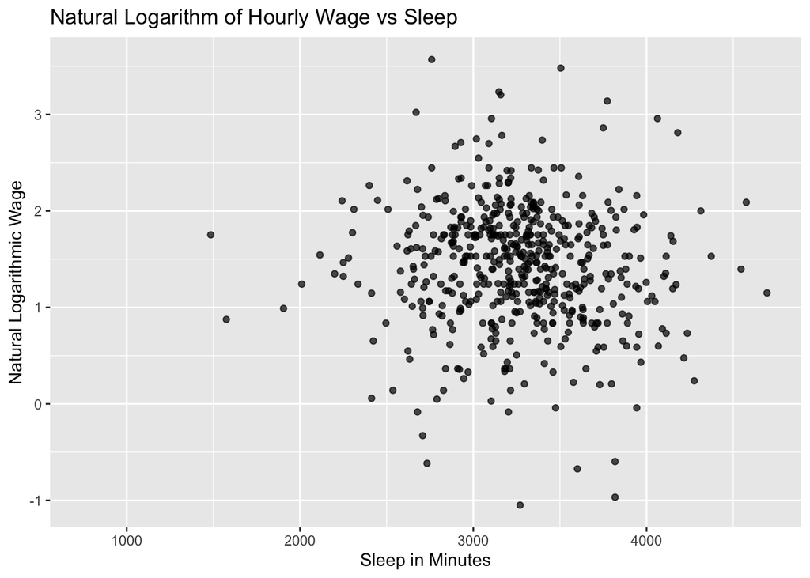

This chart reveals how the natural logarithm of hourly wage corresponds to the amount of minutes spent sleeping.

#### Purpose

The purpose behind this plot is to reveal if there is any correlation between wage and sleep. The plot revealed that there is a large cluster around 3100 minutes and a logarithmic wage of 1-2 which suggests that individuals who sleep around 3100 minutes a week (or about 7.4 hours a day) are more likely to have their logarithmic wage fall in between 1-2.

#### Insights

- As the amount of sleep in minutes gets closer to 3100, the average natural logarithmic wage becomes around 1.5.
  - This suggests that if an individual sleeps, on average, 3100 minutes a week that they are more their natural logarithmic is more likely to be close to 1.5.
- Within the data, however, there are still some outliers:
  - We can see that at around 3100 minutes that there are some individuals who’s natural logarithmic wage is significantly higher and this could be caused by the few individuals who have much larger wages while working the same amount as others.
  - We also can see outliers at around 1000-2000 minutes of sleep range which can suggest that there may be individuals who are able to work and earn a wage close to the average while not needing as much sleep.
  - We can also see outliers at around 4200-4700 minutes of sleep range which can suggest that these individuals might have a much healthier work-life balance which results in them gaining more sleep.

### Chart 3 : Relationship Between Experience and Total Hours Worked Per Day

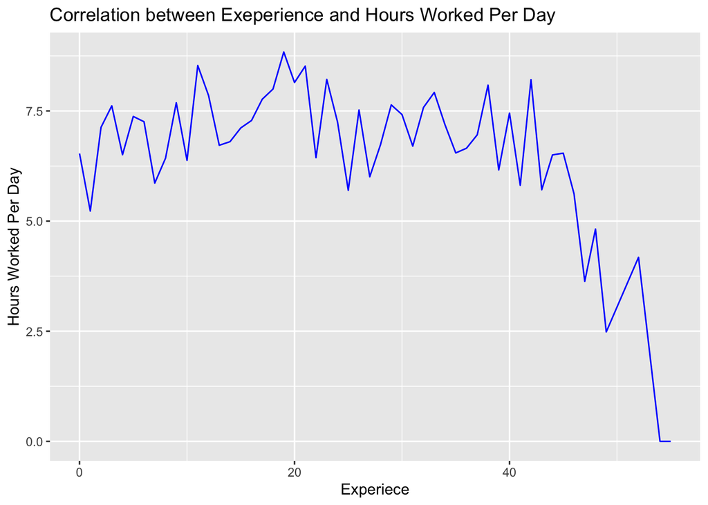

#### Purpose

This chart allows us to see if people work more/less or if there is no change as they get more experienced. This allows us to understand the work balance as people get older and go further in the industry. It also lets us relate the graphs through the connection between age and experience. If we understand what factors lead people to work more, sleep less, we can have an easier time remidying those changes.